# Part II - (CAD Analysis for men)

## by (Ezealigo Uchechukwu)

## Investigation Overview

The dataset 'DataClean-fullage' is clean and tidy and was obtained from Kaggle website. Research has reported that there is a connection between heart failure and coronary artery disease (CAD). People with CAD are very like to have their heart fail, and such a condition is both caused or exacerbated by over 26 conditions including lifestyle. CAD is one of the early signs of heart disease marked by the formation of plaque in the walls of the arteries that channels blood to the heart. My focus is to identify the number of males from the given population with CAD and associated illness like diabetes and hypertension.

## Dataset Overview

The original dataset has 6611 rows and 53 columns, then the dataset of focus has 11 columns only because we were interested on the patients with CAD, heart failure, hypertension, and diabetes.

Selected variables include: age, gender, day_icu, outcome, diabetes, hypertension, cad, cardiomyopathy, heart_failure, pulmonary_embolism and glucose. These variables were analysed to give the key insight enumerated above.

### Among the heart disease, which of them is the most prevalent?

From the data, CAD heart disese is the most prevalent compared to heart failure and cardiomyopathy, having 70% of the total patients.

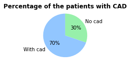

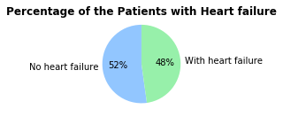

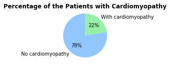

### What could be the key factor(s) for having CAD?

Hypertension followed by diabetes are key factors responsible for CAD. However, there may be some patients that may have both hypertension and diabetes which we shall consider in subsequent slide.

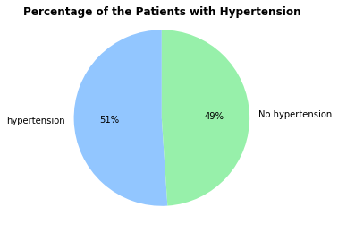

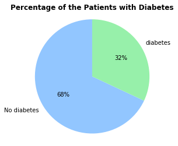

### Categorizing patients investigated based on gender: which gender is highly prone to CAD?

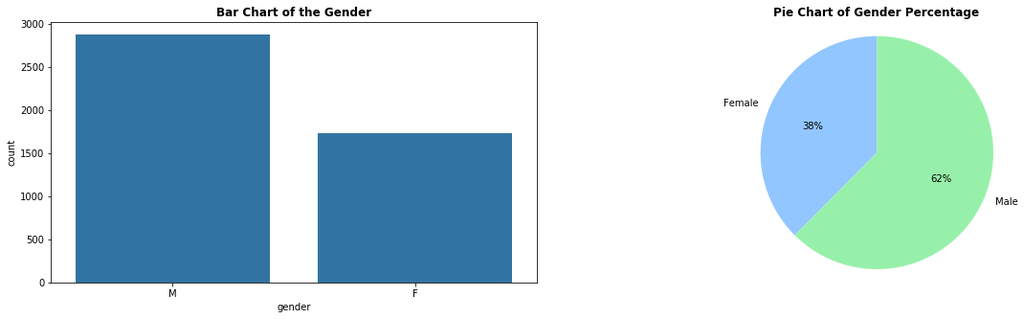

### Based on gender, what is the number of patient with other health condition?

Apart from CAD, the male gender were also more prone to having heart failure and cardiomyopathy than females.

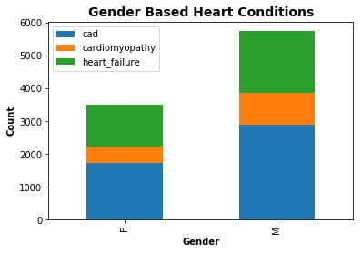

### Red Alert for Men

Beyond gender, the number of men with heart related disease and conditions is overwhelmingly high.

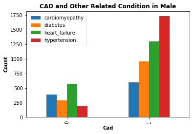

### Men, beware of high blood sugar!

Men with CAD and diabetes are more prone to having hypertension than those with other heart conditions.

### Diabetes and hypertension

The risk of having CAD is very high when the patient suffers hypertension and diabetes.

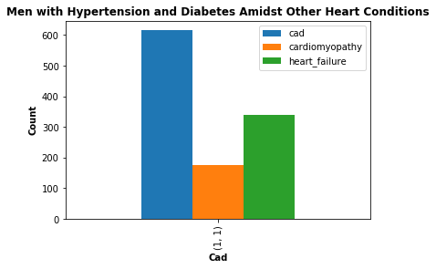

### The number of men discharged compared to DAMA and Expiry

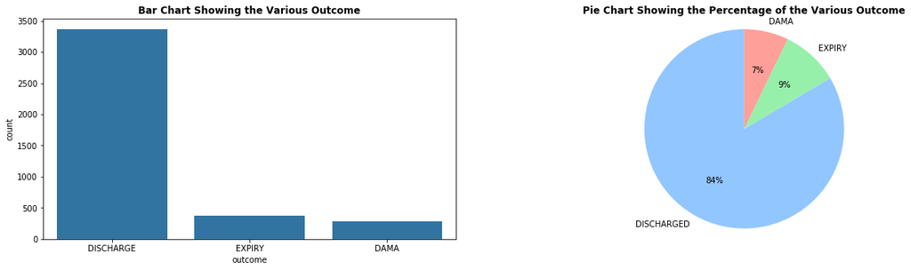

### Categorizing the male gender by age: what age category has the highest count?

The men in the elderly followed by the middle aged men categories were the highest compared to juveniles, young, senile and long livers.

```
Text(0.5,1,'Age category in Male')
```

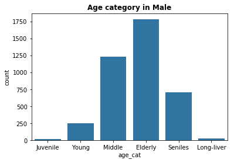

### At what age should men be mindful of their blood glucose concentration?

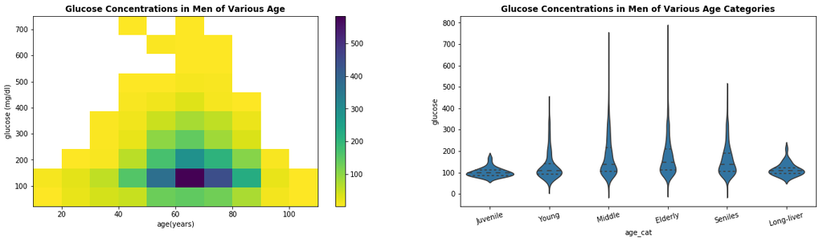

### How does blood glucose concentration affect the men with or without CAD based on age category?

The glucose concentration for the middle aged, elderly, and senile men was high for those with cad compared to the juveniles, young and long livers with or without CAD.

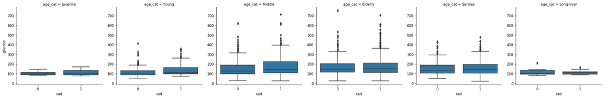

### Is there a connection with the number of days in the icu and men with or without CAD based on age category?

Any male at any age category with or without CAD can spend similar number of days in the icu except for the juveniles with CAD. Men in the age category of young may slightly begin to visit hospital but obviously at 50 years through to 70 years. Their visit and the number of days spent in the intensive care unit of the hospital may increase as year increases.

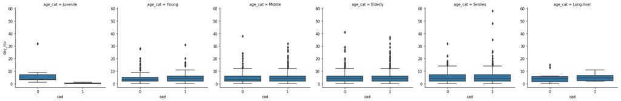

### What are the age categories that have both CAD and diabetes?

The juveniles and the young have no report of CAD and diabetes while the middle, elderly, senile and long livers are diabetic and CAD. Although, there are males in the elderly and senile categories that do not have CAD but are diabetic while in both the middle and long livers, there males that do not have both CAD and diabetes.

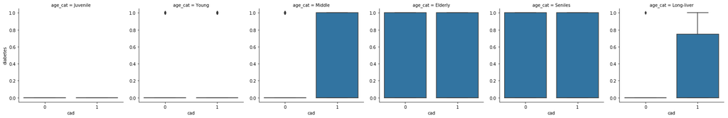

### What age category is largely at the risk of having both hypertension and diabetes?

The juveniles and the young have no report of hypertension and diabetes while the middle, elderly, senile and long livers are diabetic and hypertensive. Also, the elderly and elderly can be diabetic and not hypertensive. Similarly, there can be diabetic males without hypertension in males of senile and long liver category.

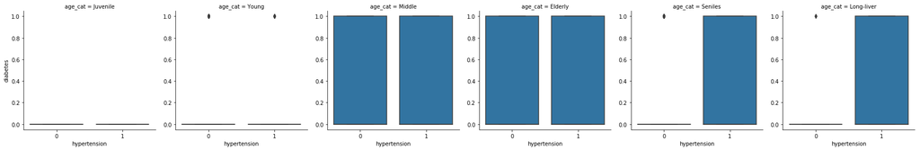

### What age category is highly prone to hypertension and CAD?

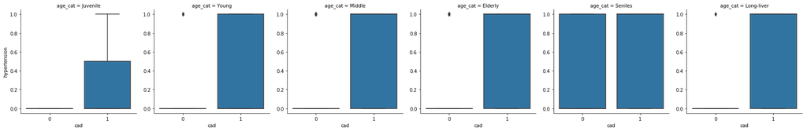